# Aplicación de los Índices en Modelos Bifactor

Asignatura: Validez

Brian N. Peña-Calero

Universidad Complutense de Madrid

01 abril, 2024

## Evaluaciones de los índices en Bifactor

Rodriguez, Reise, y Haviland (2016) indica 3 aspectos interpretativos relevantes en los índices bifactor:

1. **¿Los puntajes totales reflejan variación en una sola variable latente?** (Indicadores: $\omega$, $\omega_H$); y, de forma relacionada, ¿los puntajes de subescala reflejan varianza confiable independiente del factor general? (Indicadores: $\omega_S$, $\omega_{HS}$)
2. **¿Pueden los ítems usarse para especificar variables latentes en un contexto SEM?** Indicadores: FD, H
3. **¿Son las medidas esencialmente unidimensionales y, por lo tanto, deben especificarse como una única variable latente en SEM?**  
   Indicadores: ECV, PUC

## Puntajes Totales

$$\omega =
\frac{
\Bigl(\sum \lambda_{\text{gen}}\Bigr)^2
+ \sum_{k=1}^K \Bigl(\sum \lambda_{\text{grp}_k}\Bigr)^2
}{
\Bigl(\sum \lambda_{\text{gen}}\Bigr)^2
+ \sum_{k=1}^K \Bigl(\sum \lambda_{\text{grp}_k}\Bigr)^2
+ \sum \bigl(1 - h^2\bigr)
}$$

- $\lambda_{\text{gen}}$: Cargas factoriales de los ítems sobre el **factor general**.
- $\lambda_{\text{grp}_k}$: Cargas factoriales de los ítems sobre el **factor específico** (o grupo)
- $1-h^2$: Representa el error de medición.

## Puntajes Totales

En tanto, el $omega_H$ estudia esta varianza común pero solo la parte que se encuentra atribuída al Factor General, eliminando la parte de los factores específicos.

$$\omega_H =
\frac{
\Bigl(\sum \lambda_{\text{gen}}\Bigr)^2
}{
\Bigl(\sum \lambda_{\text{gen}}\Bigr)^2
+ \sum_{k=1}^K \Bigl(\sum \lambda_{\text{grp}_k}\Bigr)^2
+ \sum \bigl(1 - h^2\bigr)
}$$

- $\lambda_{\text{gen}}$: Cargas factoriales de los ítems sobre el **factor general**.
- $\lambda_{\text{grp}_k}$: Cargas factoriales de los ítems sobre el **factor específico** (o grupo)
- $1-h^2$: Representa el error de medición.

## Puntajes Sub-Escala:

Estima la fiabilidad de la sub-escala contando la varianza común del factor general y del factor en específico. Habitualmente esto, podría ser alto y sería un peligro evaluarlo así.

$$\omega_S \;=\;
\frac{
\Bigl(\sum \lambda_{\text{gen}}\Bigr)^2
\;+\;
\Bigl(\sum \lambda_{k=1}\Bigr)^2
}{
\Bigl(\sum \lambda_{\text{gen}}\Bigr)^2
\;+\;
\Bigl(\sum \lambda_{k=1}\Bigr)^2
\;+\;
\sum \bigl(1 - h^2\bigr)
}$$

- $\lambda_{\text{gen}}$: Cargas factoriales de los ítems sobre el **factor general**.
- $\lambda_{\text{grp}_k}$: Cargas factoriales de los ítems sobre el **factor específico** (o grupo)
- $1-h^2$: Representa el error de medición.

## Puntajes Sub-Escala:

Este omega jerárquico evaluado en la sub-escala, evalúa que tanto de la varianza común del factor específico es únicamente del factor específico. *Si el modelo bifactor ideal no se sostiene, este indicador debería ser alto*.

$$\omega_{HS} =
\frac{
\Bigl(\sum \lambda_{\text{grp}_k}\Bigr)^2
}{
\Bigl(\sum \lambda_{\text{gen}}\Bigr)^2
+ \sum_{k=1}^K \Bigl(\sum \lambda_{\text{grp}_k}\Bigr)^2
+ \sum \bigl(1 - h^2\bigr)
}$$

- $\lambda_{\text{gen}}$: Cargas factoriales de los ítems sobre el **factor general**.
- $\lambda_{\text{grp}_k}$: Cargas factoriales de los ítems sobre el **factor específico** (o grupo)
- $1-h^2$: Representa el error de medición.

## Índices de FD y H

Para evaluar si los ítems son adecuados para definir variables latentes en un modelo SEM, se utilizan:

- **Factor Determinacy (FD):**  
  Mide la correlación entre los puntajes estimados y la verdadera variable latente. Valores cercanos a 1 indican que el factor está bien definido.

  $$FD \;=\;
  \operatorname{diag}\Bigl(\Phi \,\Lambda^T\, \Sigma^{-1}\,\Lambda \,\Phi\Bigr)^{\tfrac{1}{2}}$$

## Índices de FD y H

Para evaluar si los ítems son adecuados para definir variables latentes en un modelo SEM, se utilizan:

- **Índice H (Construct Replicability):**  
  Indica qué tan bien está definido el constructo a partir de sus indicadores. Se suele considerar un valor H ≥ 0.80 como indicador de un constructo robusto.

  $$H \;=\;
  \frac{1}{
  1 \;+\; \dfrac{1}{
  \displaystyle \sum_{i=1}^k \dfrac{\lambda_i^2}{1 - \lambda_i^2}
  }
  }$$

## Unidimensionalidad esencial

Para determinar si la medida puede tratarse como esencialmente unidimensional, se utilizan:

- **Explained Common Variance (ECV):**
  $$\text{ECV} \;=\;
  \frac{
  \sum \lambda_{\text{gen}}^2
  }{
  \sum \lambda_{\text{gen}}^2
  + \sum_{k=1}^K \sum \lambda_{\text{grp}_k}^2
  }$$
  Un valor alto (p.ej., > 0.70) sugiere que la mayor parte de la varianza común se debe al factor general.

## Unidimensionalidad esencial

Para determinar si la medida puede tratarse como esencialmente unidimensional, se utilizan:

- **Percentage of Uncontaminated Correlations (PUC):**  
  Mide el porcentaje de correlaciones entre ítems que son atribuibles únicamente al factor general.  
  Un PUC elevado (por ejemplo, > 0.80) refuerza la interpretación unidimensional.

  $$\text{PUC} \;=\;
  1 \;-\;
  \frac{
  \text{número de correlaciones entre ítems del mismo factor}
  }{
  \text{número total de correlaciones}
  }$$

# Ejemplificación de un Bifactor Perfecto

## Ejemplificación

Con una muestra suficiente, 4 factores con 6 ítems en cada factor y un buen comportamiento bifactorial.

```r
library(lavaan)
library(semPlot)
library(BifactorIndicesCalculator)
source("simulaBifactor.R")

result_ideal <- simulaBifactor(
  sampleSize = 1000,
  nFactors = 4,
  itemsPerFactor = 6,
  loadingGeneral = 0.8,
  loadingSpecific = 0.3,
  fluctuation = 0.05,
  type_problematic = "perfect",
  estimator = "MLR"
)
```

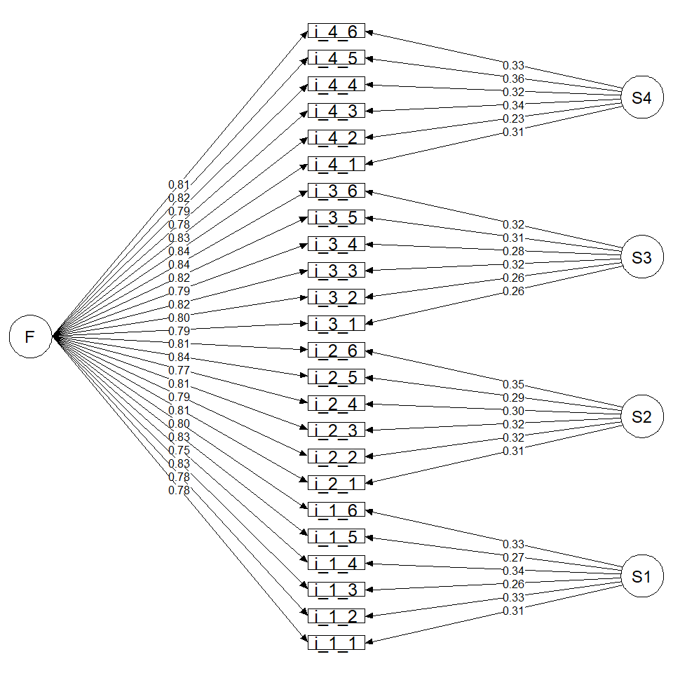

## ¿Y si fuera multifactorial?

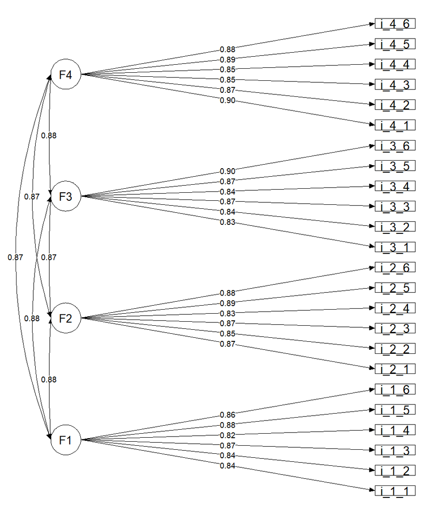

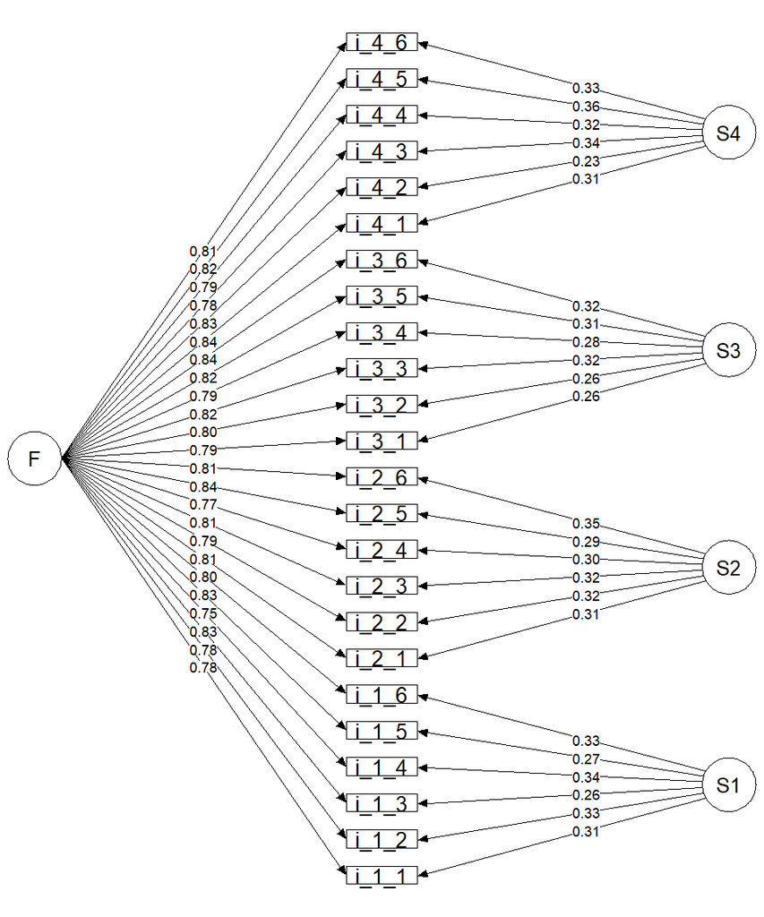

## Solución multifactorial

```r
summary(result_ideal$fit_multi, fit.measures = TRUE, standardized = TRUE)
```

```
lavaan 0.6-19 ended normally after 39 iterations

  Estimator                                         ML
  Optimization method                           NLMINB
  Number of model parameters                        54

  Number of observations                          1000

Model Test User Model:
                                              Standard      Scaled
  Test Statistic                               259.862     261.970
  Degrees of freedom                               246         246
  P-value (Chi-square)                           0.260       0.231
  Scaling correction factor                                  0.992
    Yuan-Bentler correction (Mplus variant)

Model Test Baseline Model:

  Test statistic                             25410.561   25585.788
  Degrees of freedom                               276         276
  P-value                                        0.000       0.000
  Scaling correction factor                                  0.993

User Model versus Baseline Model:

  Comparative Fit Index (CFI)                    0.999       0.999
  Tucker-Lewis Index (TLI)                       0.999       0.999

  Robust Comparative Fit Index (CFI)                         0.999
  Robust Tucker-Lewis Index (TLI)                            0.999

Loglikelihood and Information Criteria:

  Loglikelihood user model (H0)             -21424.967  -21424.967
  Scaling correction factor                                  0.994
      for the MLR correction
  Loglikelihood unrestricted model (H1)     -21295.036  -21295.036
  Scaling correction factor                                  0.992
      for the MLR correction

```

[output cut: 86 more lines]

```
   .item_3_2          0.303    0.015   20.201    0.000    0.303    0.295
   .item_3_3          0.224    0.012   18.394    0.000    0.224    0.235
   .item_3_4          0.280    0.014   20.203    0.000    0.280    0.290
   .item_3_5          0.234    0.012   19.969    0.000    0.234    0.237
   .item_3_6          0.188    0.011   17.091    0.000    0.188    0.186
   .item_4_1          0.196    0.011   18.287    0.000    0.196    0.198
   .item_4_2          0.238    0.012   20.650    0.000    0.238    0.245
   .item_4_3          0.289    0.015   19.303    0.000    0.289    0.285
   .item_4_4          0.268    0.013   20.226    0.000    0.268    0.278
   .item_4_5          0.213    0.012   18.443    0.000    0.213    0.212
   .item_4_6          0.239    0.012   19.440    0.000    0.239    0.234
    F1                1.000                               1.000    1.000
    F2                1.000                               1.000    1.000
    F3                1.000                               1.000    1.000
    F4                1.000                               1.000    1.000
```

```r
summary(result_ideal$fit_bifactor, fit.measures = TRUE, standardized = TRUE)
```

```
lavaan 0.6-19 ended normally after 35 iterations

  Estimator                                         ML
  Optimization method                           NLMINB
  Number of model parameters                        72

  Number of observations                          1000

Model Test User Model:
                                              Standard      Scaled
  Test Statistic                               218.905     221.095
  Degrees of freedom                               228         228
  P-value (Chi-square)                           0.656       0.616
  Scaling correction factor                                  0.990
    Yuan-Bentler correction (Mplus variant)

Model Test Baseline Model:

  Test statistic                             25410.561   25585.788
  Degrees of freedom                               276         276
  P-value                                        0.000       0.000
  Scaling correction factor                                  0.993

User Model versus Baseline Model:

  Comparative Fit Index (CFI)                    1.000       1.000
  Tucker-Lewis Index (TLI)                       1.000       1.000

  Robust Comparative Fit Index (CFI)                         1.000
  Robust Tucker-Lewis Index (TLI)                            1.000

Loglikelihood and Information Criteria:

  Loglikelihood user model (H0)             -21404.488  -21404.488
  Scaling correction factor                                  1.000
      for the MLR correction
  Loglikelihood unrestricted model (H1)     -21295.036  -21295.036
  Scaling correction factor                                  0.992
      for the MLR correction

```

[output cut: 117 more lines]

```
   .item_3_3          0.220    0.013   17.540    0.000    0.220    0.230
   .item_3_4          0.282    0.014   19.908    0.000    0.282    0.292
   .item_3_5          0.231    0.013   18.380    0.000    0.231    0.234
   .item_3_6          0.184    0.012   15.055    0.000    0.184    0.183
   .item_4_1          0.198    0.011   17.371    0.000    0.198    0.200
   .item_4_2          0.242    0.011   21.445    0.000    0.242    0.249
   .item_4_3          0.283    0.016   18.195    0.000    0.283    0.279
   .item_4_4          0.266    0.014   18.615    0.000    0.266    0.276
   .item_4_5          0.204    0.012   17.281    0.000    0.204    0.203
   .item_4_6          0.236    0.013   17.944    0.000    0.236    0.231
    F                 1.000                               1.000    1.000
    S1                1.000                               1.000    1.000
    S2                1.000                               1.000    1.000
    S3                1.000                               1.000    1.000
    S4                1.000                               1.000    1.000
```

## Organización de las cargas factoriales

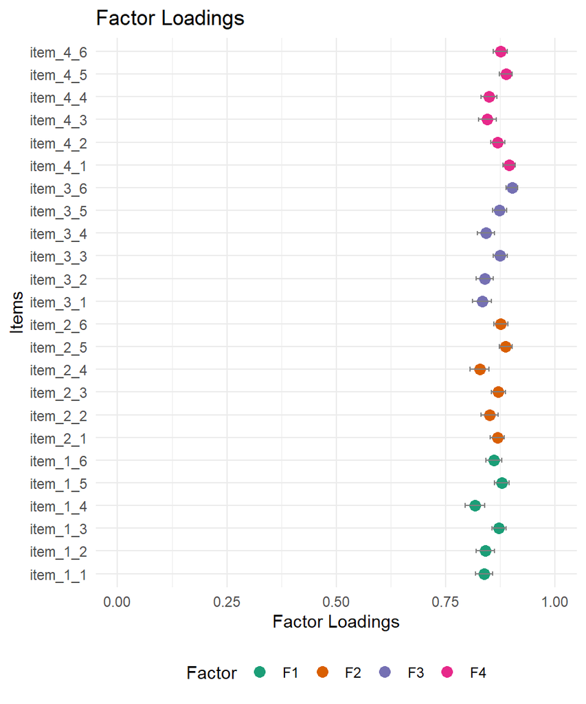

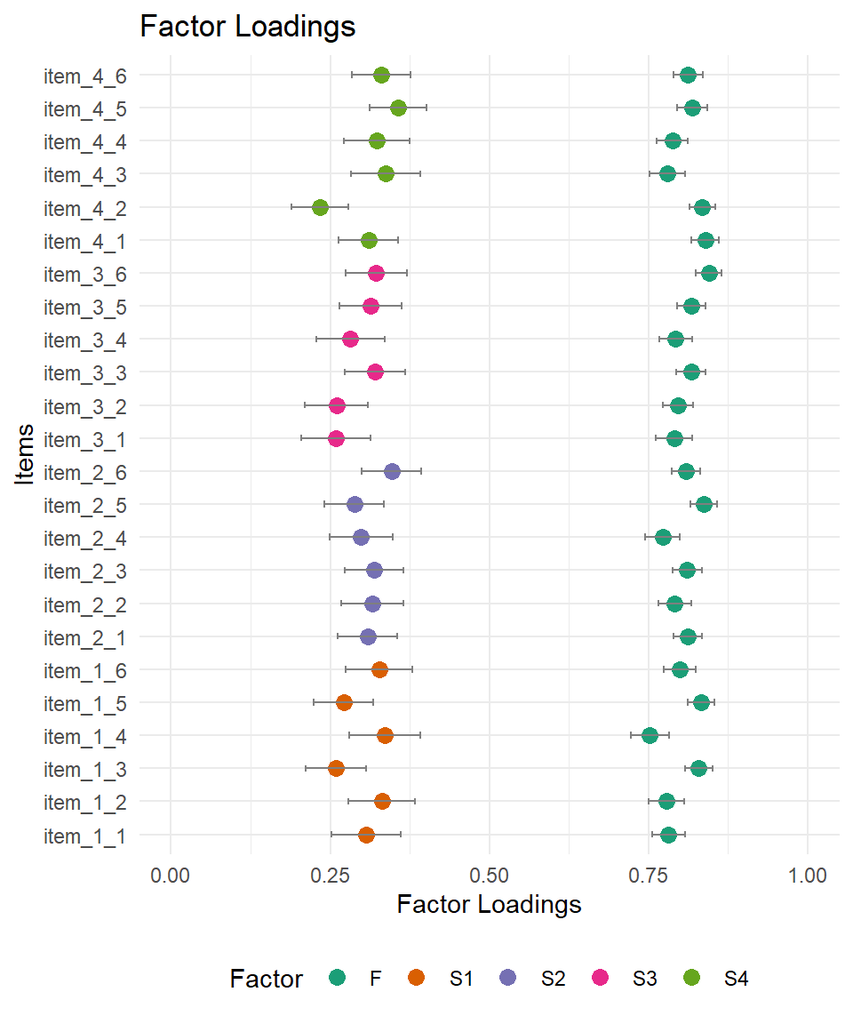

## Obtención de Índices

```r
bifactorIndices(result_ideal$fit_bifactor)
```

```
$ModelLevelIndices
    ECV.F       PUC   Omega.F  OmegaH.F
0.8725078 0.7826087 0.9843833 0.9499692

$FactorLevelIndices
      ECV_SS     ECV_SG    ECV_GS     Omega    OmegaH         H        FD
F  0.8725078 0.87250776 0.8725078 0.9843833 0.9499692 0.9783633 0.9753907
S1 0.1292968 0.03159233 0.8707032 0.9410352 0.1208026 0.3847117 0.7239138
S2 0.1314340 0.03298034 0.8685660 0.9464750 0.1240935 0.3954727 0.7380738
S3 0.1164400 0.02903263 0.8835600 0.9451736 0.1092838 0.3628306 0.7176394
S4 0.1326829 0.03388694 0.8673171 0.9499120 0.1244707 0.4037519 0.7475393

$ItemLevelIndices
              IECV
item_1_1 0.8663711
item_1_2 0.8468204
item_1_3 0.9107551
item_1_4 0.8336930
item_1_5 0.9040772
item_1_6 0.8565822
item_2_1 0.8734484
item_2_2 0.8625154
item_2_3 0.8655268
item_2_4 0.8699025
item_2_5 0.8943523
item_2_6 0.8452077
item_3_1 0.9029532
item_3_2 0.9037996
item_3_3 0.8668107
item_3_4 0.8878542
item_3_5 0.8718484
item_3_6 0.8728099
item_4_1 0.8797296
item_4_2 0.9271263
item_4_3 0.8427286
item_4_4 0.8558483
item_4_5 0.8404893
item_4_6 0.8576274
```

# Ejemplificación de un Bifactor con FE dominante

## Ejemplificación

```r
result_1f <- simulaBifactor(
  sampleSize = 1000,
  nFactors = 4,
  itemsPerFactor = 6,
  loadingGeneral = 0.8,
  loadingSpecific = 0.3,
  fluctuation = 0.05,
  type_problematic = "1f",
  mod_gen_factor = 0.3,
  mod_spec_factor = 2.5,
  estimator = "MLR"
)
```

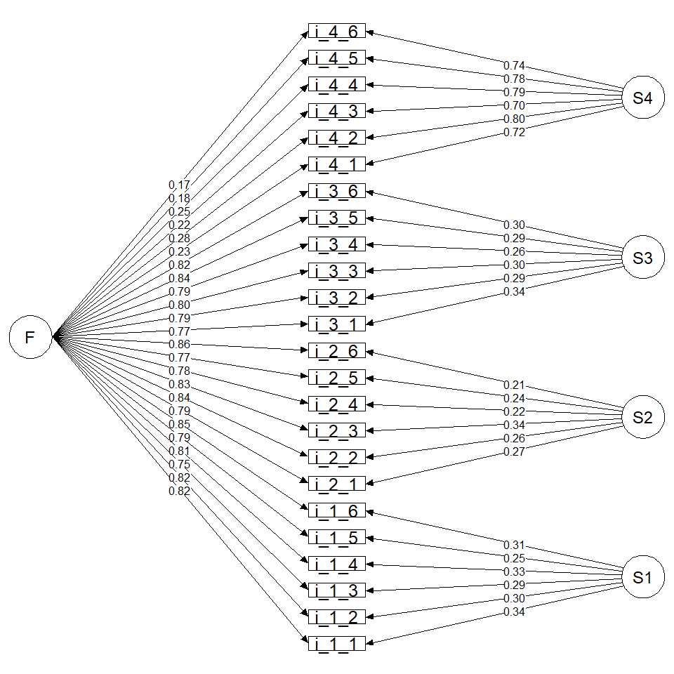

## Organización de las cargas factoriales

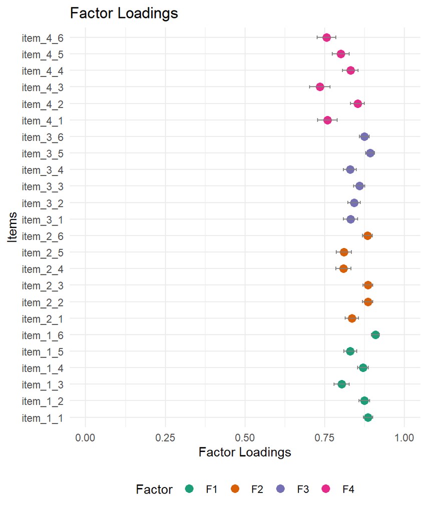

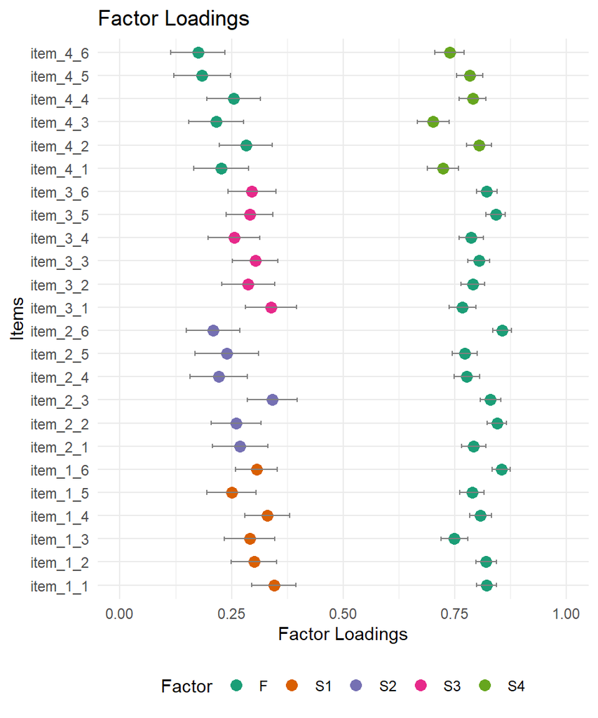

## Obtención de Índices

```r
bifactorIndices(result_1f$fit_bifactor)
```

```
$ModelLevelIndices
    ECV.F       PUC   Omega.F  OmegaH.F
0.7092450 0.7826087 0.9756456 0.8734116

$FactorLevelIndices
      ECV_SS     ECV_SG     ECV_GS     Omega     OmegaH         H        FD
F  0.7092450 0.70924504 0.70924504 0.9756456 0.87341158 0.9723392 0.9706618
S1 0.1249617 0.03289755 0.87503826 0.9459429 0.11735934 0.3822071 0.7117094
S2 0.0931025 0.02395440 0.90689750 0.9412297 0.08555391 0.3059599 0.6461961
S3 0.1199021 0.03099282 0.88009787 0.9423043 0.11240116 0.3665504 0.6916047
S4 0.9182949 0.20291019 0.08170505 0.9088727 0.83633782 0.8930512 0.9498901

$ItemLevelIndices
               IECV
item_1_1 0.85009284
item_1_2 0.88169397
item_1_3 0.86928444
item_1_4 0.85675198
item_1_5 0.90870438
item_1_6 0.88631630
item_2_1 0.89637677
item_2_2 0.91353256
item_2_3 0.85503152
item_2_4 0.92492100
item_2_5 0.91226530
item_2_6 0.94388272
item_3_1 0.83728707
item_3_2 0.88324132
item_3_3 0.87527953
item_3_4 0.90444452
item_3_5 0.89339748
item_3_6 0.88565039
item_4_1 0.08932164
item_4_2 0.10964869
item_4_3 0.08602536
item_4_4 0.09423379
item_4_5 0.05222418
item_4_6 0.05293116
```

## References

Rodriguez, Anthony, Steven P. Reise, y Mark G. Haviland. 2016. «Applying Bifactor Statistical Indices in the Evaluation of Psychological Measures». *Journal of Personality Assessment* 98 (3): 223-37. https://doi.org/10.1080/00223891.2015.1089249.